# CaseStudy

João Pedro Demambro

2025-02-18

## Introdução e objetivos

O Acordo de Livre Comércio (ALC) Mercosul/Israel foi firmado em 18 de dezembro de 2007 e entrou em vigor em 28 de abril de 2010. De acordo com o Siscomex, trata-se do primeiro tratado “dessa modalidade a ser celebrado pelo bloco sul-americano com um país localizado fora de nosso continente”. O texto fundador do ALC define como objetivos: 1. eliminar as barreiras ao comércio de bens e facilitar sua circulação entre os territórios das Partes; 2. promover as condições de livre concorrência na área de livre comércio; 3. aumentar substancialmente as oportunidades de investimento nos territórios das Partes e aumentar a cooperação em áreas que sejam de interesse mútuo das Partes; 4. criar procedimentos eficazes para a implementação, aplicação e cumprimento deste Acordo e sua administração conjunta; e 5. estabelecer um marco para aprofundar a cooperação bilateral e multilateral para expandir e ampliar os benefícios do Acordo.

Nesse sentido, o presente estudo tem o intuito de explorar os dados relativos ao comércio entre as partes entre os anos 2021 e 2024. Pretende-se criar uma versão atualizada do informe de relações comerciais do Mercosul com Israel, cuja última publicação disponível no Sistema de Estatísticas de Comércio Exterior do Mercosul (SECEM) refere-se aos anos 2016-2020.

Para isso, usaremos as informações disponibilizadas no Sistema de Estatísticas de Comércio Exterior do Mercosul (SECEM) e no ComexStat.

## Carregando os pacotes e importando o arquivo

```r
mercosul_israel_historico <- read.csv("C:/Users/User/Downloads/NCM.csv")
library(ggplot2)
library(dplyr)
library(scales)  # Para formatar os valores como dólares
library(tidyr)
```

## Explorando os dados

Vamos começar com uma funções básica que sintetiza os dados do arquivo importado

```r
glimpse(mercosul_israel_historico)
```

```
## Rows: 7,584
## Columns: 8
## $ NCM                 <int> 2012090, 2013000, 2013000, 2013000, 2013000, 20220…
## $ Descripción         <chr> "Cortes de carne bovina fresca o refrigerada s/des…
## $ Año                 <int> 2024, 2021, 2022, 2023, 2024, 2023, 2024, 2021, 20…
## $ Exportaciones       <dbl> 2.00, 102297063.56, 130316420.94, 120146978.61, 13…
## $ Importaciones..FOB. <dbl> 0.00, 0.00, 0.00, 0.00, 0.00, 0.00, 0.00, 0.00, 15…
## $ Importaciones..CIF. <dbl> 0.00, 0.00, 0.00, 0.00, 0.00, 0.00, 0.00, 0.00, 15…
## $ Volumen.Exports     <dbl> 2.00, 16110369.35, 18253832.76, 19726544.80, 22558…
## $ Volumen.Imports     <dbl> 0.00, 0.00, 0.00, 0.00, 0.00, 0.00, 0.00, 0.00, 26…
```

Percebe-se que a tabela possui 7584 linhas, 8 colunas e se refere aos anos 2021-2024.Para evitar problemas com a coluna “Año” em espanhol, vamos corrigir para “Ano”.

```r
# Renomear a coluna "Año" para "Ano"
mercosul_israel_corrigido <- mercosul_israel_historico %>%
  rename(Ano = `Año`)
glimpse(mercosul_israel_corrigido)
```

```
## Rows: 7,584
## Columns: 8
## $ NCM                 <int> 2012090, 2013000, 2013000, 2013000, 2013000, 20220…
## $ Descripción         <chr> "Cortes de carne bovina fresca o refrigerada s/des…
## $ Ano                 <int> 2024, 2021, 2022, 2023, 2024, 2023, 2024, 2021, 20…
## $ Exportaciones       <dbl> 2.00, 102297063.56, 130316420.94, 120146978.61, 13…
## $ Importaciones..FOB. <dbl> 0.00, 0.00, 0.00, 0.00, 0.00, 0.00, 0.00, 0.00, 15…
## $ Importaciones..CIF. <dbl> 0.00, 0.00, 0.00, 0.00, 0.00, 0.00, 0.00, 0.00, 15…
## $ Volumen.Exports     <dbl> 2.00, 16110369.35, 18253832.76, 19726544.80, 22558…
## $ Volumen.Imports     <dbl> 0.00, 0.00, 0.00, 0.00, 0.00, 0.00, 0.00, 0.00, 26…
```

Agora, faremos uma nova tabela agrupada por ano com informações resumidas dos valores exportações e importações em FOB.

```r
sumario_historico <- mercosul_israel_corrigido %>%
  group_by(Ano) %>%
  summarise(soma_importacao = sum(Importaciones..FOB.), soma_exportacao = sum(Exportaciones))
print(sumario_historico)
```

```
## # A tibble: 4 × 3
##     Ano soma_importacao soma_exportacao
##   <int>           <dbl>           <dbl>
## 1  2021     1310019822.     1214935995.
## 2  2022     2354864047.     2518467840.
## 3  2023     1611045051.     1147837512.
## 4  2024     1036126757.     1181531351.
```

A partir dessa tabela, podemos fazer um gráfico de barras empilhadas para visualizar os dados da balança comercial Mercosul-Israel nos anos acima.

### Balança Comercial Mercosul-Israel

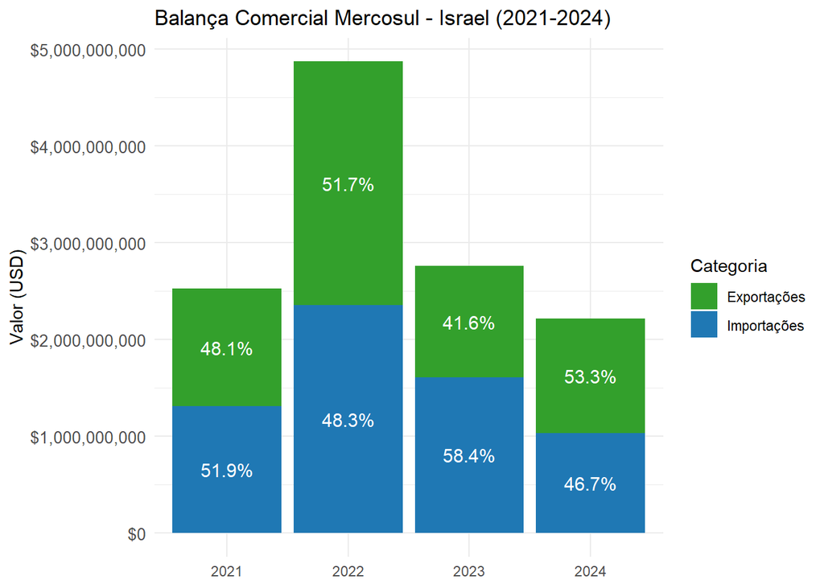

```r
# Transformar os dados para formato longo (necessário para gráfico empilhado)
sumario_historico_long <- sumario_historico %>%
  select(Ano, soma_importacao, soma_exportacao) %>%
  pivot_longer(cols = c(soma_importacao, soma_exportacao),
               names_to = "Tipo",
               values_to = "Valor") %>%
  group_by(Ano) %>%
  mutate(Percentual = Valor / sum(Valor) * 100)  # Calcula a porcentagem dentro de cada ano

# Criar gráfico de colunas empilhadas com porcentagem
ggplot(sumario_historico_long, aes(x = factor(Ano), y = Valor, fill = Tipo)) +
  geom_bar(stat = "identity") +  # Usa os valores reais
  geom_text(aes(label = paste0(round(Percentual, 1), "%")),
            position = position_stack(vjust = 0.5),  # Posiciona os rótulos no meio de cada segmento
            color = "white", size = 4) +  # Define cor branca para contraste e tamanho do texto
  scale_y_continuous(labels = dollar_format(prefix = "$", big.mark = ",")) +  # Formato em dólares
  scale_fill_manual(values = c("soma_importacao" = "#1f78b4", "soma_exportacao" = "#33a02c"),
                    labels = c("soma_importacao" = "Importações", "soma_exportacao" = "Exportações")) +
  labs(title = "Balança Comercial Mercosul - Israel (2021-2024)",
       x = NULL,  # Remove legenda do eixo X
       y = "Valor (USD)",
       fill = "Categoria") +
  theme_minimal() +
  theme(axis.title.x = element_blank(),  # Remove título do eixo X
        axis.text.y = element_text(size = 10))  # Diminui tamanho do texto do eixo Y
```

Com efeito, observa-se que o Mercosul obteve superávit na balança comercial com Israel nos anos de 2022 e 2024, ao passo que enfrentou déficit nos anos de 2021 e 2023, neste último com a maior disparidade no período analisado.

### Produtos mais exportados e importados

Agora, podemos aprofundar esses dados mais gerais e criar um gráfico de pizza que permita a visualização dos cinco produtos mais exportados pelo Mercosul.Faremos isso facetando nos anos 2021, 2022, 2023 e 2024, vendo os maiores valores da coluna “Exportaciones” e retornando o “NCM” com a descrição adicionada do tipo de produto.

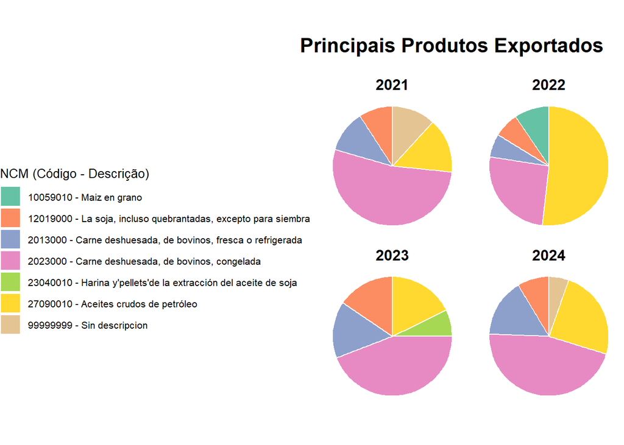

```r
# Criar dicionário com descrições dos produtos NCM
descricao_ncm <- c(
  "2013000" = "Carne deshuesada, de bovinos, fresca o refrigerada",
  "10059010" = "Maiz en grano",
  "23040010" = "Harina y'pellets'de la extracción del aceite de soja",
  "99999999" = "Sin descripcion",
  "2023000" = "Carne deshuesada, de bovinos, congelada",
  "12019000" = "La soja, incluso quebrantadas, excepto para siembra",
  "27090010" = "Aceites crudos de petróleo"
)

# Selecionar os principais produtos exportados por ano e calcular porcentagens
top_exportados <- mercosul_israel_corrigido %>%
  group_by(Ano) %>%
  arrange(desc(Exportaciones)) %>%
  slice_max(order_by = Exportaciones, n = 5) %>%
  mutate(
    total_ano = sum(Exportaciones),  # Soma total de exportações por ano
    pct = (Exportaciones / total_ano) * 100,  # Calcula a porcentagem
    NCM_desc = coalesce(descricao_ncm[as.character(NCM)], "Descrição não disponível"),  # Evita NA
    NCM = paste(NCM, "-", NCM_desc)  # Concatena código e descrição
  ) %>%
  ungroup()  # Remove agrupamento para evitar problemas no ggplot

# Criar gráfico de pizza (sem rótulos de porcentagem)
ggplot(top_exportados, aes(x = "", y = Exportaciones, fill = factor(NCM))) +
  geom_bar(stat = "identity", width = 1, color = "white") +  # Adiciona borda branca para separar fatias
  coord_polar(theta = "y") +  # Converte para gráfico de pizza
  facet_wrap(~Ano, scales = "free_y", ncol = 2) +  # Organiza em 2 colunas
  scale_fill_brewer(palette = "Set2") +  # Cores distintas
  labs(title = "Principais Produtos Exportados",
       fill = "NCM (Código - Descrição)") +
  theme_void() +  # Remove eixos para aparência de pizza
  theme(
    legend.position = "left",  # Coloca a legenda na parte inferior
    legend.title = element_text(size = 10),  # Tamanho da legenda (título)
    legend.text = element_text(size = 8),  # Tamanho da legenda (texto)
    strip.text = element_text(size = 12, face = "bold"),  # Tamanho dos títulos dos anos
    plot.title = element_text(
      size = 16,              # Tamanho do título
      face = "bold",           # Negrito
      hjust = -6.0,             # Centraliza horizontalmente
      vjust = 0.2,             # Ajusta a posição vertical
      margin = margin(b = 20)  # Adiciona margem na parte inferior do título
    )
  )  # Melhora a legibilidade do gráfico
```

Vemos, portanto, que a exportação de produtos agropecuários é a pauta mais importante do bloco mercosulino a Israel. Destacam-se a carne bovina e a soja. O aumento das exportações de petróleo a partir de 2022 amplia a diversidade da pauta exportadora, embora o setor primário ainda predomine.

Repetiremos o mesmo procedimento agora analisando as importações. Faremos o gráfico de pizza com os principais produtos importados facetado por ano.

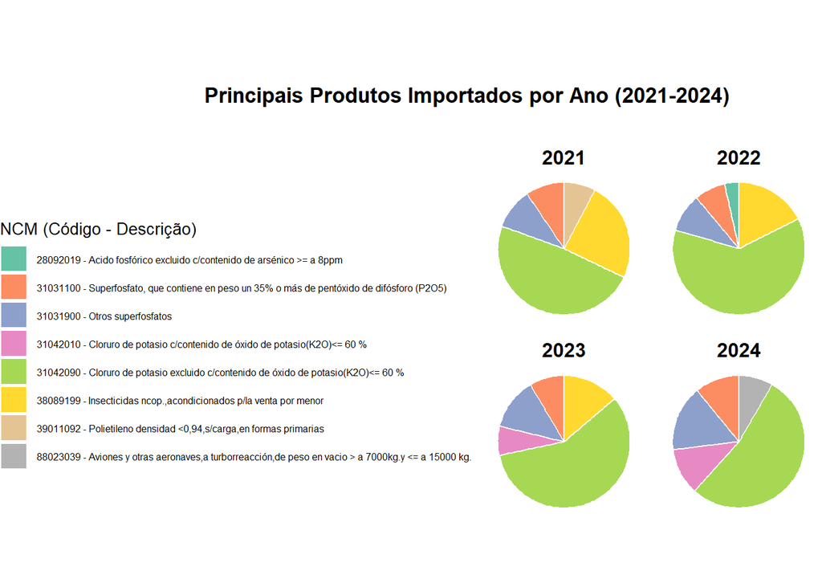

```r
# Selecionar os principais produtos importados por ano e calcular porcentagens
top_produtos_importados <- mercosul_israel_historico %>%
  group_by(Año) %>%
  arrange(desc(Importaciones..FOB.)) %>%
  slice_max(order_by = Importaciones..FOB., n = 5) %>%  # Top 5 por ano
  mutate(
    total_ano = sum(Importaciones..FOB., na.rm = TRUE),  # Total por ano
    pct = (Importaciones..FOB. / total_ano) * 100,       # Porcentagem
    NCM_desc = paste(NCM, "-", Descripción)              # Junta código NCM com descrição
  ) %>%
  ungroup()

# Criar gráfico de pizza facetado por ano
ggplot(top_produtos_importados, aes(x = "", y = Importaciones..FOB., fill = factor(NCM_desc))) +
  geom_bar(stat = "identity", width = 1, color = "white") +  # Borda branca para separar fatias
  coord_polar(theta = "y") +  # Converte para gráfico de pizza
  facet_wrap(~ Año, scales = "free_y", ncol = 2) +  # Faceta por ano em 2 colunas
  scale_fill_brewer(palette = "Set2") +  # Cores distintas
  labs(title = "Principais Produtos Importados por Ano (2021-2024)",
       fill = "NCM (Código - Descrição)") +
  theme_void() +  # Remove eixos para aparência limpa
  theme(
    legend.position = "left",  # Legenda à esquerda
    legend.title = element_text(size = 10),
    legend.text = element_text(size = 6),
    strip.text = element_text(size = 12, face = "bold"),  # Títulos dos anos
    plot.title = element_text(
      size = 13, face = "bold", hjust = 1.5, margin = margin(t = 15, b = 25)  # Título à esquerda e mais baixo
    ),
  )
```

### Participação nas exportações e importações

Agora vamos ver os dados de exportação e calcular a participação de cada um nas exportações a Israel.

```r
ano <- c(2021, 2022, 2023, 2024)
argentina <- c(366419999.52, 401205883.13, 341151581.18, 435264709.63)
brasil <- c(597929632.00, 1883531876.00, 661876638.00, 640734177.00)
uruguai <- c(93471620.00, 90145328.00, 61021233.00, 95387874.00)
paraguai <- c(157114743.00, 143584752.47, 83788059.61, 127327868.18)
total <- c(1214935994.52, 2518467839.60, 1147837511.79, 1298714628.81)
```

Vamos criar um dataframe com o total das exportações a Israel de modo a calcular a participação de cada membro.

```r
totalmercosur <- data.frame(ano, argentina, brasil, uruguai, paraguai, total)
print(totalmercosur)
```

```
##    ano argentina     brasil  uruguai  paraguai      total
## 1 2021 366420000  597929632 93471620 157114743 1214935995
## 2 2022 401205883 1883531876 90145328 143584752 2518467840
## 3 2023 341151581  661876638 61021233  83788060 1147837512
## 4 2024 435264710  640734177 95387874 127327868 1298714629
```

```r
# Converter para formato longo (long format) e calcular porcentagem
dados_long <- totalmercosur %>%
  pivot_longer(cols = argentina:paraguai, names_to = "pais", values_to = "valor") %>%
  mutate(percentual = (valor / total) * 100) # Calcular a porcentagem
print(dados_long)
```

```
## # A tibble: 16 × 5
##      ano       total pais            valor percentual
##    <dbl>       <dbl> <chr>           <dbl>      <dbl>
##  1  2021 1214935995. argentina  366420000.      30.2
##  2  2021 1214935995. brasil     597929632       49.2
##  3  2021 1214935995. uruguai     93471620        7.69
##  4  2021 1214935995. paraguai   157114743       12.9
##  5  2022 2518467840. argentina  401205883.      15.9
##  6  2022 2518467840. brasil    1883531876       74.8
##  7  2022 2518467840. uruguai     90145328        3.58
##  8  2022 2518467840. paraguai   143584752.       5.70
##  9  2023 1147837512. argentina  341151581.      29.7
## 10  2023 1147837512. brasil     661876638       57.7
## 11  2023 1147837512. uruguai     61021233        5.32
## 12  2023 1147837512. paraguai    83788060.       7.30
## 13  2024 1298714629. argentina  435264710.      33.5
## 14  2024 1298714629. brasil     640734177       49.3
## 15  2024 1298714629. uruguai     95387874        7.34
## 16  2024 1298714629. paraguai   127327868.       9.80
```

Agora vamos ao gráfico:

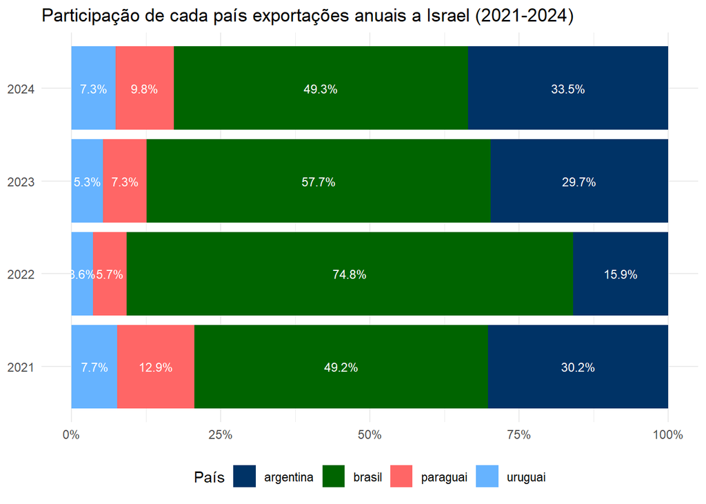

```r
# Criar gráfico de barras empilhadas na horizontal com cores personalizadas
ggplot(dados_long, aes(y = factor(ano), x = percentual, fill = pais)) +
  geom_bar(stat = "identity") +
  geom_text(aes(label = paste0(round(percentual, 1), "%")),
            position = position_stack(vjust = 0.5), size = 3, color = "white") +
  scale_fill_manual(values = c("argentina" = "#003366",  # Azul escuro
                               "brasil" = "#006400",    # Verde
                               "uruguai" = "#66B3FF",  # Azul claro
                               "paraguai" = "#FF6666")) +  # Vermelho claro
  labs(title = "Participação de cada país exportações anuais a Israel (2021-2024)",
       x = NULL, y = NULL, fill = "País") +
  scale_x_continuous(labels = scales::percent_format(scale = 1)) +
  theme_minimal() +
  theme(legend.position = "bottom") # Move a legenda para baixo
```

Em todos os anos analisados observa-se o mesmo padrão sequencial de Brasil, Argentina, Paraguai e Uruguai. O Brasil obteve o pico no ano de 2022, com cerca de 75% das exportações totais do bloco mercosulino. Paraguai e Uruguai mantiveram índices próximos, mas ainda distantes da Argentina. A distribuição das exportações foi mais equilibrada nos anos de 2021 e 2024, quando a dominância brasileira foi mais suavizada.

Agora vamos ver os dados de importação e calcular a participação de cada um.

```r
ano_imp <- c(2021, 2022, 2023, 2024)
argentina_imp <- c(147990763.11, 186541840.61, 177503205.49, 98645155.33)
brasil_imp <- c(1140434812.00, 2118511799.00, 1351954197.00, 878906730.00)
uruguai_imp <- c(11595393.69, 24938002.86, 36013880.64, 20482251.93)
paraguai_imp <- c(9998853.00, 24872404.42, 45573768.08, 38092619.72)
imp_ano <- c(147990763.11 + 1140434812.00 + 11595393.69 + 9998853.00, 186541840.61 + 2118511799.00 + 24938002.86 + 24872404.42, 177503205.49 + 1351954197.00 + 36013880.64 + 45573768.08, 98645155.33 + 878906730.00 + 20482251.93 + 38092619.72)
total_imp <- data.frame(ano_imp, argentina_imp, brasil_imp, uruguai_imp, paraguai_imp, imp_ano)
print(total_imp)
```

```
##   ano_imp argentina_imp brasil_imp uruguai_imp paraguai_imp    imp_ano
## 1    2021     147990763 1140434812    11595394      9998853 1310019822
## 2    2022     186541841 2118511799    24938003     24872404 2354864047
## 3    2023     177503205 1351954197    36013881     45573768 1611045051
## 4    2024      98645155  878906730    20482252     38092620 1036126757
```

```r
# Converter a tabela para formato longo (long format)
dados_imp_long <- total_imp %>%
  pivot_longer(cols = argentina_imp:paraguai_imp, names_to = "pais", values_to = "valor") %>%
  mutate(percentual = (valor / imp_ano) * 100)  # Calcular a porcentagem de cada país nas importações
print(dados_imp_long)
```

```
## # A tibble: 16 × 5
##    ano_imp     imp_ano pais                valor percentual
##      <dbl>       <dbl> <chr>               <dbl>      <dbl>
##  1    2021 1310019822. argentina_imp  147990763.     11.3
##  2    2021 1310019822. brasil_imp    1140434812      87.1
##  3    2021 1310019822. uruguai_imp     11595394.      0.885
##  4    2021 1310019822. paraguai_imp     9998853       0.763
##  5    2022 2354864047. argentina_imp  186541841.      7.92
##  6    2022 2354864047. brasil_imp    2118511799      90.0
##  7    2022 2354864047. uruguai_imp     24938003.      1.06
##  8    2022 2354864047. paraguai_imp    24872404.      1.06
##  9    2023 1611045051. argentina_imp  177503205.     11.0
## 10    2023 1611045051. brasil_imp    1351954197      83.9
## 11    2023 1611045051. uruguai_imp     36013881.      2.24
## 12    2023 1611045051. paraguai_imp    45573768.      2.83
## 13    2024 1036126757. argentina_imp   98645155.      9.52
## 14    2024 1036126757. brasil_imp     878906730      84.8
## 15    2024 1036126757. uruguai_imp     20482252.      1.98
## 16    2024 1036126757. paraguai_imp    38092620.      3.68
```

Vamos ao gráfico!

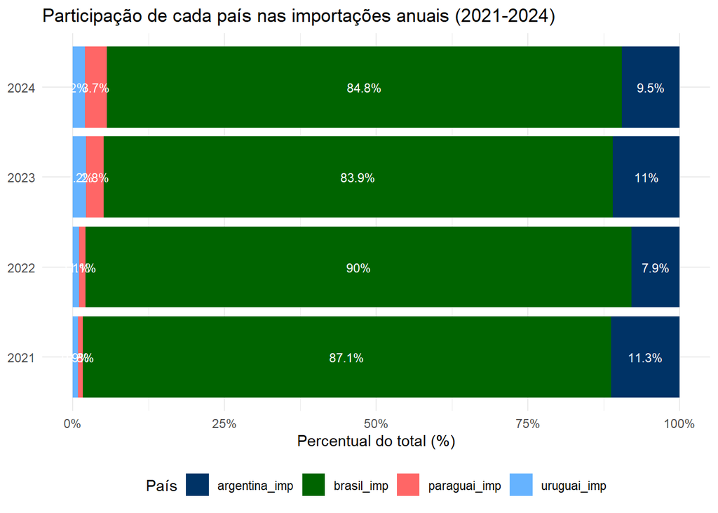

```r
# Criar gráfico de barras empilhadas na horizontal para importações com rótulos
ggplot(dados_imp_long, aes(y = factor(ano_imp), x = percentual, fill = pais)) +
  geom_bar(stat = "identity") +
  geom_text(aes(label = paste0(round(percentual, 1), "%")),
            position = position_stack(vjust = 0.5), size = 3, color = "white") +
  scale_fill_manual(values = c("argentina_imp" = "#003366",  # Azul escuro
                               "brasil_imp" = "#006400",    # Verde
                               "uruguai_imp" = "#66B3FF",  # Azul claro
                               "paraguai_imp" = "#FF6666")) +  # Vermelho claro
  labs(title = "Participação de cada país nas importações anuais (2021-2024)",
       x = "Percentual do total (%)", y = NULL, fill = "País") +
  scale_x_continuous(labels = scales::percent_format(scale = 1)) +
  theme_minimal() +
  theme(legend.position = "bottom")
```

## Conclusões

- A balança comercial do Mercosul foi equilibrada, com superávits nos anos de 2022 e 2024 e déficits nos anos de 2021 e 2023. Em 2023, houve a maior disparidade com uma diferença de 16,8% a favor de Israel.
- Os principais produtos exportados pelo Mercosul são do ramo agropecuário. Carne bovina e soja são os produtos dominantes desse setor. Por outro lado, observou-se um aumento das exportações de petróleo a partir de 2022, o que pode indicar uma diversificação da pauta.
- Quanto à participação nas exportações, o padrão consiste na sequência de Brasil, Argentina, Paraguai e Uruguai. Nos anos de 2021 e 2024, percebe-se um certo equilíbrio na distribuição, de modo que a primazia brasileira, ainda que existente, foi mais relativizada.
- Os principais produtos importados pelo bloco são aqueles associados ao agronegócio, sobretudo fertilizantes e defensivos. O ano de 2024 se destacou com a presença de aeronaves na lista. No entanto, dada a ausência de produção nacional dos produtos agrícolas referidos, é provável que eles continuem a dominar a pauta de importações do bloco mercosulino em relação a Israel.